# Entering the Tidyverse

02 December, 2019

## CodeR TSV

### Our Joruney so far…

1. Intro to Rmarkdown (Ira)
2. Intro to Git/GitHub (Cesar)
3. Intro to the Tidyverse (Me)
4. How about a Recap/Hack Session? (Dec 9th)

### Our Resources

- GitHub Orgnaisation
- Slack Group
- Hex Stick!!
- What else do we want?

## Now Entering the Tidyverse

- What is the “tidyverse”
- How do you use it?
- Give it a go!

## Now Entering the Tidyverse

Website: https://www.tidyverse.org

### Cheat Sheet

[figure not shown]

#### More Cheat sheets:

- Rstudio -> Help -> Cheatsheets -> Browse Cheatsheets
- https://rstudio.com/resources/cheatsheets/

## What is the Tidyverse?

- An opionated list of useful packages
- **One package to rule them all!!**
- R packages for preparing, wrangling and visualizing data
- Often refered to as the “Hadleyverse”

[figure not shown]

[figure not shown]

[figure not shown]

## Load the tidyverse

```r
library(tidyverse)
```

## Load the tidyverse

```r
tidyverse_packages()
```

```
##  [1] "broom"      "cli"        "crayon"     "dbplyr"     "dplyr"
##  [6] "forcats"    "ggplot2"    "haven"      "hms"        "httr"
## [11] "jsonlite"   "lubridate"  "magrittr"   "modelr"     "pillar"
## [16] "purrr"      "readr"      "readxl"     "reprex"     "rlang"
## [21] "rstudioapi" "rvest"      "stringr"    "tibble"     "tidyr"
## [26] "xml2"       "tidyverse"
```

## Pipe (%>%) Operator

- The “%>%” is the “Pipe” operator
- Forward a value, or the result of an expression, into the next function call/expression

```r
cars %>% filter(speed >= 10)
```

```
##    speed dist
## 1     10   18
## 2     10   26
## 3     10   34
## 4     11   17
## 5     11   28
## 6     12   14
## 7     12   20
## 8     12   24
## 9     12   28
## 10    13   26
## 11    13   34
## 12    13   34
## 13    13   46
## 14    14   26
```

[output cut: 30 more lines]

## Pipe (%>%) Operator

- Reduces the amoung of code you write
- More reable
- Can pipe directly into a plot

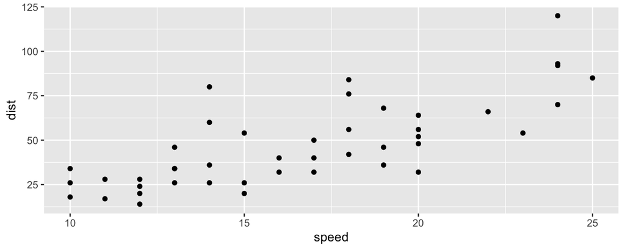

```r
cars %>% filter(speed >= 10) %>%
  ggplot() + geom_point(aes(x = speed, y = dist))
```

## Reading Data

### readr

The goal of readr is to provide a fast and friendly way to read rectangular data (like csv, tsv, and fwf). It is designed to flexibly parse many types of data found in the wild, while still cleanly failing when data unexpectedly changes

### readxl

The readxl package makes it easy to get data out of Excel and into R.

[figure not shown]

## readr

```r
read_csv(readr_example("mtcars.csv"))
```

```
## # A tibble: 32 x 11
##      mpg   cyl  disp    hp  drat    wt  qsec    vs    am  gear  carb
##    <dbl> <dbl> <dbl> <dbl> <dbl> <dbl> <dbl> <dbl> <dbl> <dbl> <dbl>
##  1  21       6  160    110  3.9   2.62  16.5     0     1     4     4
##  2  21       6  160    110  3.9   2.88  17.0     0     1     4     4
##  3  22.8     4  108     93  3.85  2.32  18.6     1     1     4     1
##  4  21.4     6  258    110  3.08  3.22  19.4     1     0     3     1
##  5  18.7     8  360    175  3.15  3.44  17.0     0     0     3     2
##  6  18.1     6  225    105  2.76  3.46  20.2     1     0     3     1
##  7  14.3     8  360    245  3.21  3.57  15.8     0     0     3     4
##  8  24.4     4  147.    62  3.69  3.19  20       1     0     4     2
##  9  22.8     4  141.    95  3.92  3.15  22.9     1     0     4     2
## 10  19.2     6  168.   123  3.92  3.44  18.3     1     0     4     4
## # … with 22 more rows
```

## readxls

```r
library(readxl)
read_excel(readxl_example("datasets.xlsx"))
```

```
## # A tibble: 150 x 5
##    Sepal.Length Sepal.Width Petal.Length Petal.Width Species
##           <dbl>       <dbl>        <dbl>       <dbl> <chr>
##  1          5.1         3.5          1.4         0.2 setosa
##  2          4.9         3            1.4         0.2 setosa
##  3          4.7         3.2          1.3         0.2 setosa
##  4          4.6         3.1          1.5         0.2 setosa
##  5          5           3.6          1.4         0.2 setosa
##  6          5.4         3.9          1.7         0.4 setosa
##  7          4.6         3.4          1.4         0.3 setosa
##  8          5           3.4          1.5         0.2 setosa
##  9          4.4         2.9          1.4         0.2 setosa
## 10          4.9         3.1          1.5         0.1 setosa
## # … with 140 more rows
```

## The Tibble

### What is a “Tibble”

> A tibble, or tbl_df, is a modern reimagining of the data.frame, keeping what time has proven to be effective, and throwing out what is not. Tibbles are data.frames that are lazy and surly: they do less (i.e. they don’t change variable names or types, and don’t do partial matching) and complain more (e.g. when a variable does not exist). This forces you to confront problems earlier, typically leading to cleaner, more expressive code. Tibbles also have an enhanced print() method which makes them easier to use with large datasets containing complex objects.

## The Tibble

### What is a “Tibble”

```r
library(tibble)
as_tibble(iris)
```

```
## # A tibble: 150 x 5
##    Sepal.Length Sepal.Width Petal.Length Petal.Width Species
##           <dbl>       <dbl>        <dbl>       <dbl> <fct>
##  1          5.1         3.5          1.4         0.2 setosa
##  2          4.9         3            1.4         0.2 setosa
##  3          4.7         3.2          1.3         0.2 setosa
##  4          4.6         3.1          1.5         0.2 setosa
##  5          5           3.6          1.4         0.2 setosa
##  6          5.4         3.9          1.7         0.4 setosa
##  7          4.6         3.4          1.4         0.3 setosa
##  8          5           3.4          1.5         0.2 setosa
##  9          4.4         2.9          1.4         0.2 setosa
## 10          4.9         3.1          1.5         0.1 setosa
## # … with 140 more rows
```

## The Tibble

### Glimpse a tibble

```r
library(tibble)
as_tibble(iris) %>% glimpse()
```

```
## Observations: 150
## Variables: 5
## $ Sepal.Length <dbl> 5.1, 4.9, 4.7, 4.6, 5.0, 5.4, 4.6, 5.0, 4.4, 4.9, 5.4, 4…
## $ Sepal.Width  <dbl> 3.5, 3.0, 3.2, 3.1, 3.6, 3.9, 3.4, 3.4, 2.9, 3.1, 3.7, 3…
## $ Petal.Length <dbl> 1.4, 1.4, 1.3, 1.5, 1.4, 1.7, 1.4, 1.5, 1.4, 1.5, 1.5, 1…
## $ Petal.Width  <dbl> 0.2, 0.2, 0.2, 0.2, 0.2, 0.4, 0.3, 0.2, 0.2, 0.1, 0.2, 0…
## $ Species      <fct> setosa, setosa, setosa, setosa, setosa, setosa, setosa, …
```

## Wrangling Data

### filter()

Easily filter your data

```r
as_tibble(iris) %>% filter(Species == "setosa", Sepal.Length >= 5)
```

```
## # A tibble: 30 x 5
##    Sepal.Length Sepal.Width Petal.Length Petal.Width Species
##           <dbl>       <dbl>        <dbl>       <dbl> <fct>
##  1          5.1         3.5          1.4         0.2 setosa
##  2          5           3.6          1.4         0.2 setosa
##  3          5.4         3.9          1.7         0.4 setosa
##  4          5           3.4          1.5         0.2 setosa
##  5          5.4         3.7          1.5         0.2 setosa
##  6          5.8         4            1.2         0.2 setosa
##  7          5.7         4.4          1.5         0.4 setosa
##  8          5.4         3.9          1.3         0.4 setosa
##  9          5.1         3.5          1.4         0.3 setosa
## 10          5.7         3.8          1.7         0.3 setosa
## # … with 20 more rows
```

## Wrangling Data

### select() & rename()

When only want certain columns and you want to rename them

```r
iris %>% as_tibble() %>% select(Species, contains("Length"))
```

```
## # A tibble: 150 x 3
##    Species Sepal.Length Petal.Length
##    <fct>          <dbl>        <dbl>
##  1 setosa           5.1          1.4
##  2 setosa           4.9          1.4
##  3 setosa           4.7          1.3
##  4 setosa           4.6          1.5
##  5 setosa           5            1.4
##  6 setosa           5.4          1.7
##  7 setosa           4.6          1.4
##  8 setosa           5            1.5
##  9 setosa           4.4          1.4
## 10 setosa           4.9          1.5
## # … with 140 more rows
```

## Wrangling Data

### select() & rename()

When only want certain columns and you want to rename them

```r
iris %>% as_tibble() %>% select(Flower = Species, contains("Length"))
```

```
## # A tibble: 150 x 3
##    Flower Sepal.Length Petal.Length
##    <fct>         <dbl>        <dbl>
##  1 setosa          5.1          1.4
##  2 setosa          4.9          1.4
##  3 setosa          4.7          1.3
##  4 setosa          4.6          1.5
##  5 setosa          5            1.4
##  6 setosa          5.4          1.7
##  7 setosa          4.6          1.4
##  8 setosa          5            1.5
##  9 setosa          4.4          1.4
## 10 setosa          4.9          1.5
## # … with 140 more rows
```

## Wrangling Data

### select() & rename()

When only want certain columns and you want to rename them

```r
iris %>% as_tibble() %>% rename(Flower = Species)
```

```
## # A tibble: 150 x 5
##    Sepal.Length Sepal.Width Petal.Length Petal.Width Flower
##           <dbl>       <dbl>        <dbl>       <dbl> <fct>
##  1          5.1         3.5          1.4         0.2 setosa
##  2          4.9         3            1.4         0.2 setosa
##  3          4.7         3.2          1.3         0.2 setosa
##  4          4.6         3.1          1.5         0.2 setosa
##  5          5           3.6          1.4         0.2 setosa
##  6          5.4         3.9          1.7         0.4 setosa
##  7          4.6         3.4          1.4         0.3 setosa
##  8          5           3.4          1.5         0.2 setosa
##  9          4.4         2.9          1.4         0.2 setosa
## 10          4.9         3.1          1.5         0.1 setosa
## # … with 140 more rows
```

## Wrangling Data

### select() & rename()

When only want certain columns and you want to rename them

```r
iris %>% as_tibble() %>% rename(Flower = Species) %>% select(Flower, everything())
```

```
## # A tibble: 150 x 5
##    Flower Sepal.Length Sepal.Width Petal.Length Petal.Width
##    <fct>         <dbl>       <dbl>        <dbl>       <dbl>
##  1 setosa          5.1         3.5          1.4         0.2
##  2 setosa          4.9         3            1.4         0.2
##  3 setosa          4.7         3.2          1.3         0.2
##  4 setosa          4.6         3.1          1.5         0.2
##  5 setosa          5           3.6          1.4         0.2
##  6 setosa          5.4         3.9          1.7         0.4
##  7 setosa          4.6         3.4          1.4         0.3
##  8 setosa          5           3.4          1.5         0.2
##  9 setosa          4.4         2.9          1.4         0.2
## 10 setosa          4.9         3.1          1.5         0.1
## # … with 140 more rows
```

## Wrangling Data

### group_by() & summarise()

Great for when you have different group that you want to summarise

```r
iris %>%
  group_by(Species) %>%
  summarise(n = n(), mean.sepal.length = mean(Sepal.Length))
```

```
## # A tibble: 3 x 3
##   Species        n mean.sepal.length
##   <fct>      <int>             <dbl>
## 1 setosa        50              5.01
## 2 versicolor    50              5.94
## 3 virginica     50              6.59
```

## Wrangling Data

### group_by() & summarise()

Great for when you have different group that you want to summarise

```r
iris %>%
  group_by(Species) %>%
  summarise_all(list(mean = mean))
```

```
## # A tibble: 3 x 5
##   Species   Sepal.Length_mean Sepal.Width_mean Petal.Length_me… Petal.Width_mean
##   <fct>                 <dbl>            <dbl>            <dbl>            <dbl>
## 1 setosa                 5.01             3.43             1.46            0.246
## 2 versicol…              5.94             2.77             4.26            1.33
## 3 virginica              6.59             2.97             5.55            2.03
```

## Wrangling Data

### mutate(), transmute(), case_when()

mutate() for when you want to make a new variable, or modify exisiting variable

```r
mtcars %>% as_tibble() %>% mutate(
  cyl2 = cyl * 2,
  cyl4 = cyl2 * 2
)
```

```
## # A tibble: 32 x 13
##      mpg   cyl  disp    hp  drat    wt  qsec    vs    am  gear  carb  cyl2  cyl4
##    <dbl> <dbl> <dbl> <dbl> <dbl> <dbl> <dbl> <dbl> <dbl> <dbl> <dbl> <dbl> <dbl>
##  1  21       6  160    110  3.9   2.62  16.5     0     1     4     4    12    24
##  2  21       6  160    110  3.9   2.88  17.0     0     1     4     4    12    24
##  3  22.8     4  108     93  3.85  2.32  18.6     1     1     4     1     8    16
##  4  21.4     6  258    110  3.08  3.22  19.4     1     0     3     1    12    24
##  5  18.7     8  360    175  3.15  3.44  17.0     0     0     3     2    16    32
##  6  18.1     6  225    105  2.76  3.46  20.2     1     0     3     1    12    24
##  7  14.3     8  360    245  3.21  3.57  15.8     0     0     3     4    16    32
##  8  24.4     4  147.    62  3.69  3.19  20       1     0     4     2     8    16
##  9  22.8     4  141.    95  3.92  3.15  22.9     1     0     4     2     8    16
## 10  19.2     6  168.   123  3.92  3.44  18.3     1     0     4     4    12    24
## # … with 22 more rows
```

## Wrangling Data

### mutate(), transmute(), case_when()

transmute() to create new variable and kepe only that variable

```r
iris %>% as_tibble() %>% transmute(log.Petal.length = log(Petal.Length))
```

```
## # A tibble: 150 x 1
##    log.Petal.length
##               <dbl>
##  1            0.336
##  2            0.336
##  3            0.262
##  4            0.405
##  5            0.336
##  6            0.531
##  7            0.336
##  8            0.405
##  9            0.336
## 10            0.405
## # … with 140 more rows
```

## Wrangling Data

### mutate(), transmute(), case_when()

case_when() - use with mutate() like “ifelse”

```r
starwars %>% as_tibble()
```

```
## # A tibble: 87 x 13
##    name  height  mass hair_color skin_color eye_color birth_year gender
##    <chr>  <int> <dbl> <chr>      <chr>      <chr>          <dbl> <chr>
##  1 Luke…    172    77 blond      fair       blue            19   male
##  2 C-3PO    167    75 <NA>       gold       yellow         112   <NA>
##  3 R2-D2     96    32 <NA>       white, bl… red             33   <NA>
##  4 Dart…    202   136 none       white      yellow          41.9 male
##  5 Leia…    150    49 brown      light      brown           19   female
##  6 Owen…    178   120 brown, gr… light      blue            52   male
##  7 Beru…    165    75 brown      light      blue            47   female
##  8 R5-D4     97    32 <NA>       white, red red             NA   <NA>
##  9 Bigg…    183    84 black      light      brown           24   male
## 10 Obi-…    182    77 auburn, w… fair       blue-gray       57   male
## # … with 77 more rows, and 5 more variables: homeworld <chr>, species <chr>,
## #   films <list>, vehicles <list>, starships <list>
```

## Wrangling Data

### mutate(), transmute(), case_when()

case_when() - use with mutate() like “ifelse”

```r
starwars %>%
  select(name:mass, gender, species) %>%
  mutate(type = case_when(height > 200 | mass > 200 ~ "large",
      species == "Droid" ~ "robot",TRUE ~  "other"))
```

```
## # A tibble: 87 x 6
##    name               height  mass gender species type
##    <chr>               <int> <dbl> <chr>  <chr>   <chr>
##  1 Luke Skywalker        172    77 male   Human   other
##  2 C-3PO                 167    75 <NA>   Droid   robot
##  3 R2-D2                  96    32 <NA>   Droid   robot
##  4 Darth Vader           202   136 male   Human   large
##  5 Leia Organa           150    49 female Human   other
##  6 Owen Lars             178   120 male   Human   other
##  7 Beru Whitesun lars    165    75 female Human   other
##  8 R5-D4                  97    32 <NA>   Droid   robot
##  9 Biggs Darklighter     183    84 male   Human   other
## 10 Obi-Wan Kenobi        182    77 male   Human   other
## # … with 77 more rows
```

## Tidyr: Make Data Tidy Again!!

**The goal of tidyr is to help you create tidy data**

Tidy data is data where:

- Every column is variable.
- Every row is an observation.
- Every cell is a single value.

[figure not shown]

## Tidyr: the long and the wide of it

### Gather or Spread your data

The old way

- gather(): make data.frame longer
- spread(): make data.frame wider

As of tidyr v1.0

- pivot_longer(): make data.frame longer
- pivot_wider(): make data.frame wider

## Tidyr: the long and the wide of it

### Gather or Spread your data

```r
 relig_income
```

```
## # A tibble: 18 x 11
##    religion `<$10k` `$10-20k` `$20-30k` `$30-40k` `$40-50k` `$50-75k` `$75-100k`
##    <chr>      <dbl>     <dbl>     <dbl>     <dbl>     <dbl>     <dbl>      <dbl>
##  1 Agnostic      27        34        60        81        76       137        122
##  2 Atheist       12        27        37        52        35        70         73
##  3 Buddhist      27        21        30        34        33        58         62
##  4 Catholic     418       617       732       670       638      1116        949
##  5 Don’t k…      15        14        15        11        10        35         21
##  6 Evangel…     575       869      1064       982       881      1486        949
##  7 Hindu          1         9         7         9        11        34         47
##  8 Histori…     228       244       236       238       197       223        131
##  9 Jehovah…      20        27        24        24        21        30         15
## 10 Jewish        19        19        25        25        30        95         69
## 11 Mainlin…     289       495       619       655       651      1107        939
## 12 Mormon        29        40        48        51        56       112         85
## 13 Muslim         6         7         9        10         9        23         16
## 14 Orthodox      13        17        23        32        32        47         38
## 15 Other C…       9         7        11        13        13        14         18
## 16 Other F…      20        33        40        46        49        63         46
## 17 Other W…       5         2         3         4         2         7          3
## 18 Unaffil…     217       299       374       365       341       528        407
## # … with 3 more variables: `$100-150k` <dbl>, `>150k` <dbl>, `Don't
## #   know/refused` <dbl>
```

## Make Data Longer

taken from vignette(“pivot”)

```r
relig_income %>%
  pivot_longer(-religion, names_to = "income", values_to = "count")
```

```
## # A tibble: 180 x 3
##    religion income             count
##    <chr>    <chr>              <dbl>
##  1 Agnostic <$10k                 27
##  2 Agnostic $10-20k               34
##  3 Agnostic $20-30k               60
##  4 Agnostic $30-40k               81
##  5 Agnostic $40-50k               76
##  6 Agnostic $50-75k              137
##  7 Agnostic $75-100k             122
##  8 Agnostic $100-150k            109
##  9 Agnostic >150k                 84
## 10 Agnostic Don't know/refused    96
## # … with 170 more rows
```

## Make Data wider

taken from vignette(“pivot”)

```r
fish_encounters
```

```
## # A tibble: 114 x 3
##    fish  station  seen
##    <fct> <fct>   <int>
##  1 4842  Release     1
##  2 4842  I80_1       1
##  3 4842  Lisbon      1
##  4 4842  Rstr        1
##  5 4842  Base_TD     1
##  6 4842  BCE         1
##  7 4842  BCW         1
##  8 4842  BCE2        1
##  9 4842  BCW2        1
## 10 4842  MAE         1
## # … with 104 more rows
```

## Make Data wider

taken from vignette(“pivot”)

```r
fish_encounters %>% pivot_wider(names_from = station, values_from = seen)
```

```
## # A tibble: 19 x 12
##    fish  Release I80_1 Lisbon  Rstr Base_TD   BCE   BCW  BCE2  BCW2   MAE   MAW
##    <fct>   <int> <int>  <int> <int>   <int> <int> <int> <int> <int> <int> <int>
##  1 4842        1     1      1     1       1     1     1     1     1     1     1
##  2 4843        1     1      1     1       1     1     1     1     1     1     1
##  3 4844        1     1      1     1       1     1     1     1     1     1     1
##  4 4845        1     1      1     1       1    NA    NA    NA    NA    NA    NA
##  5 4847        1     1      1    NA      NA    NA    NA    NA    NA    NA    NA
##  6 4848        1     1      1     1      NA    NA    NA    NA    NA    NA    NA
##  7 4849        1     1     NA    NA      NA    NA    NA    NA    NA    NA    NA
##  8 4850        1     1     NA     1       1     1     1    NA    NA    NA    NA
##  9 4851        1     1     NA    NA      NA    NA    NA    NA    NA    NA    NA
## 10 4854        1     1     NA    NA      NA    NA    NA    NA    NA    NA    NA
## 11 4855        1     1      1     1       1    NA    NA    NA    NA    NA    NA
## 12 4857        1     1      1     1       1     1     1     1     1    NA    NA
## 13 4858        1     1      1     1       1     1     1     1     1     1     1
## 14 4859        1     1      1     1       1    NA    NA    NA    NA    NA    NA
## 15 4861        1     1      1     1       1     1     1     1     1     1     1
## 16 4862        1     1      1     1       1     1     1     1     1    NA    NA
## 17 4863        1     1     NA    NA      NA    NA    NA    NA    NA    NA    NA
## 18 4864        1     1     NA    NA      NA    NA    NA    NA    NA    NA    NA
## 19 4865        1     1      1    NA      NA    NA    NA    NA    NA    NA    NA
```

## Make Data wider

taken from vignette(“pivot”)

```r
fish_encounters %>% pivot_wider(names_from = station, values_from = seen,
                                values_fill = list(seen = 0))
```

```
## # A tibble: 19 x 12
##    fish  Release I80_1 Lisbon  Rstr Base_TD   BCE   BCW  BCE2  BCW2   MAE   MAW
##    <fct>   <int> <int>  <int> <int>   <int> <int> <int> <int> <int> <int> <int>
##  1 4842        1     1      1     1       1     1     1     1     1     1     1
##  2 4843        1     1      1     1       1     1     1     1     1     1     1
##  3 4844        1     1      1     1       1     1     1     1     1     1     1
##  4 4845        1     1      1     1       1     0     0     0     0     0     0
##  5 4847        1     1      1     0       0     0     0     0     0     0     0
##  6 4848        1     1      1     1       0     0     0     0     0     0     0
##  7 4849        1     1      0     0       0     0     0     0     0     0     0
##  8 4850        1     1      0     1       1     1     1     0     0     0     0
##  9 4851        1     1      0     0       0     0     0     0     0     0     0
## 10 4854        1     1      0     0       0     0     0     0     0     0     0
## 11 4855        1     1      1     1       1     0     0     0     0     0     0
## 12 4857        1     1      1     1       1     1     1     1     1     0     0
## 13 4858        1     1      1     1       1     1     1     1     1     1     1
## 14 4859        1     1      1     1       1     0     0     0     0     0     0
## 15 4861        1     1      1     1       1     1     1     1     1     1     1
## 16 4862        1     1      1     1       1     1     1     1     1     0     0
## 17 4863        1     1      0     0       0     0     0     0     0     0     0
## 18 4864        1     1      0     0       0     0     0     0     0     0     0
## 19 4865        1     1      1     0       0     0     0     0     0     0     0
```

## Joining tbls

### inner_join, left_join, right_join, full_join

```r
band_members
```

```
## # A tibble: 3 x 2
##   name  band
##   <chr> <chr>
## 1 Mick  Stones
## 2 John  Beatles
## 3 Paul  Beatles
```

```r
band_instruments
```

```
## # A tibble: 3 x 2
##   name  plays
##   <chr> <chr>
## 1 John  guitar
## 2 Paul  bass
## 3 Keith guitar
```

## Joining tbls

### inner_join, left_join, right_join, full_join

inner_join

> return all rows from x where there are matching values in y, and all columns from x and y

```r
band_members %>% inner_join(band_instruments)
```

```
## # A tibble: 2 x 3
##   name  band    plays
##   <chr> <chr>   <chr>
## 1 John  Beatles guitar
## 2 Paul  Beatles bass
```

## Joining tbls

### inner_join, left_join, right_join, full_join

left_join

> return all rows from x, and all columns from x and y. Rows in x with no match in y will have NA values in the new columns

```r
band_members %>% left_join(band_instruments)
```

```
## # A tibble: 3 x 3
##   name  band    plays
##   <chr> <chr>   <chr>
## 1 Mick  Stones  <NA>
## 2 John  Beatles guitar
## 3 Paul  Beatles bass
```

## Joining tbls

### inner_join, left_join, right_join, full_join

right_join

> return all rows from y, and all columns from x and y. Rows in y with no match in x will have NA values in the new columns

```r
band_members %>% right_join(band_instruments)
```

```
## # A tibble: 3 x 3
##   name  band    plays
##   <chr> <chr>   <chr>
## 1 John  Beatles guitar
## 2 Paul  Beatles bass
## 3 Keith <NA>    guitar
```

## Joining tbls

### inner_join, left_join, right_join, full_join

full_join

> return all rows and all columns from both x and y. Where there are not matching values, returns NA for the one missing.

```r
band_members %>% full_join(band_instruments)
```

```
## # A tibble: 4 x 3
##   name  band    plays
##   <chr> <chr>   <chr>
## 1 Mick  Stones  <NA>
## 2 John  Beatles guitar
## 3 Paul  Beatles bass
## 4 Keith <NA>    guitar
```

## Filter Joining tbls

### semi_join, anti_join

**semi_join** : return all rows from x where there are matching values in y, keeping just columns from x. A semi join differs from an inner join because an inner join will return one row of x for each matching row of y, where a semi join will never duplicate rows of x

```r
band_members %>% semi_join(band_instruments)
```

```
## # A tibble: 2 x 2
##   name  band
##   <chr> <chr>
## 1 John  Beatles
## 2 Paul  Beatles
```

## Filter Joining tbls

### semi_join, anti_join

**anti_join** : return all rows from x where there are not matching values in y, keeping just columns from x.

```r
band_members %>% anti_join(band_instruments)
```

```
## # A tibble: 1 x 2
##   name  band
##   <chr> <chr>
## 1 Mick  Stones
```

## Tidyverse - You can never leave…..

### This is just a taste of the verse, there are other packages and more will likely be added in the future

[figure not shown]